# ECGR 4106 Homework 1 — CIFAR-10 CNN Comparison

**Student:** Andrew Dominguez Luna  
**Course:** ECGR 4106 Deep Learning  
**Homework:** Homework 1

GitHub repository:

`https://github.com/adomin10-prog/ECGR4106-HW--CIFAR10-CNNs`

## 1. Set Google Colab to GPU

Before running:

1. Click `Runtime`
2. Click `Change runtime type`
3. Set `Hardware accelerator` to `T4 GPU`
4. Click `Save`

Running the full homework experiment on CPU is not recommended. CPU takes too long.

## 2. Clone the GitHub repository

This cell downloads the repository into Colab.

```python
import os
import shutil
from pathlib import Path

REPO_URL = "https://github.com/adomin10-prog/ECGR4106-HW--CIFAR10-CNNs.git"
REPO_DIR = Path("/content/ECGR4106-HW--CIFAR10-CNNs")

if REPO_DIR.exists():
    shutil.rmtree(REPO_DIR)

!git clone {REPO_URL} {REPO_DIR}

%cd {REPO_DIR}
print("Current folder:", Path.cwd())
```

```
Cloning into '/content/ECGR4106-HW--CIFAR10-CNNs'...
remote: Enumerating objects: 80, done.
remote: Counting objects: 100% (80/80), done.
remote: Compressing objects: 100% (75/75), done.
remote: Total 80 (delta 24), reused 0 (delta 0), pack-reused 0 (from 0)
Receiving objects: 100% (80/80), 40.94 KiB | 5.12 MiB/s, done.
Resolving deltas: 100% (24/24), done.
/content/ECGR4106-HW--CIFAR10-CNNs
Current folder: /content/ECGR4106-HW--CIFAR10-CNNs
```

## 3. Install requirements

This installs the packages listed in the repo's `requirements.txt`.

```python
%pip install -q -r requirements.txt
```

## 4. Confirm GPU and PyTorch setup

```python
import sys
import platform
import torch

print("Python:", platform.python_version())
print("PyTorch:", torch.__version__)
print("CUDA available:", torch.cuda.is_available())

device = torch.device("cuda" if torch.cuda.is_available() else "cpu")
print("Selected device:", device)

if torch.cuda.is_available():
    print("GPU:", torch.cuda.get_device_name(0))
else:
    print("WARNING: GPU is not enabled. Go to Runtime -> Change runtime type -> T4 GPU.")
```

```
Python: 3.12.13
PyTorch: 2.11.0+cu128
CUDA available: True
Selected device: cuda
GPU: NVIDIA RTX PRO 6000 Blackwell Server Edition
```

### 5. Import the code from the GitHub repository

This cell imports the existing model, data, metric, plotting, and seed functions from the repo.

```python
import csv
import json
import time
from pathlib import Path

import pandas as pd
import matplotlib.pyplot as plt

import torch
import torch.nn as nn
import torch.optim as optim

from IPython.display import display, Image

# These imports come directly from the GitHub repository files.
from models.alexnet_cifar import AlexNetCIFAR
from models.vgg_cifar import VGGCIFAR
from models.resnet_cifar import ResNet11CIFAR, ResNet18CIFAR

from utils.data import get_cifar10_loaders, CIFAR10_CLASSES
from utils.metrics import evaluate, count_trainable_parameters
from utils.plotting import plot_curves, plot_confusion_matrix
from utils.seed import set_seed

# These functions are also already defined in train.py.
from train import build_model, train_one_epoch

print("Repository code imported successfully.")
```

```
Repository code imported successfully.
```

## 7. Experiment settings

For final submission, leave:

```
RUN_FULL_HOMEWORK = True
```

```python
RUN_FULL_HOMEWORK = True

SEED = 42
BATCH_SIZE = 128
NUM_WORKERS = 2

DATA_DIR = "./data"
RESULTS_DIR = Path("./results")
RESULTS_DIR.mkdir(parents=True, exist_ok=True)

set_seed(SEED)

print("RUN_FULL_HOMEWORK:", RUN_FULL_HOMEWORK)
print("Batch size:", BATCH_SIZE)
print("Results folder:", RESULTS_DIR.resolve())
```

```
RUN_FULL_HOMEWORK: True
Batch size: 128
Results folder: /content/ECGR4106-HW--CIFAR10-CNNs/results
```

## 8. Load CIFAR-10 using the repo's data function

```python
train_loader, val_loader, test_loader = get_cifar10_loaders(
    data_dir=DATA_DIR,
    batch_size=BATCH_SIZE,
    seed=SEED,
    num_workers=NUM_WORKERS
)

print("Training batches:", len(train_loader))
print("Validation batches:", len(val_loader))
print("Test batches:", len(test_loader))

images, labels = next(iter(train_loader))
print("Image batch shape:", images.shape)
print("Label batch shape:", labels.shape)
```

```
Training batches: 352
Validation batches: 40
Test batches: 79
Image batch shape: torch.Size([128, 3, 32, 32])
Label batch shape: torch.Size([128])
```

## 9. Check model output shapes and parameter counts

The model classes come directly from the repo:

- `models/alexnet_cifar.py`
- `models/vgg_cifar.py`
- `models/resnet_cifar.py`

The `build_model()` function comes from `train.py`.

```python
model_names = ["alexnet", "vgg", "resnet11", "resnet18"]

for model_name in model_names:
    model = build_model(model_name, dropout=0.0)
    sample_output = model(torch.zeros(2, 3, 32, 32))
    params = count_trainable_parameters(model)

    print(
        f"{model_name:8s} | output shape: {tuple(sample_output.shape)} | "
        f"trainable parameters: {params:,}"
    )
```

```
alexnet  | output shape: (2, 10) | trainable parameters: 3,192,458
vgg      | output shape: (2, 10) | trainable parameters: 3,586,698
resnet11 | output shape: (2, 10) | trainable parameters: 4,903,242
resnet18 | output shape: (2, 10) | trainable parameters: 11,173,962
```

## 10. Experiment list

These are the full homework model/dropout configurations.

- AlexNet and VGG run for 30 epochs.
- ResNet-11 and ResNet-18 run for 50 epochs.
- Each model is tested with dropout values of `0.0`, `0.3`, and `0.5`.

```python
FULL_EXPERIMENTS = [
    # model, dropout, epochs, learning rate
    ("alexnet", 0.0, 30, 0.01),
    ("alexnet", 0.3, 30, 0.01),
    ("alexnet", 0.5, 30, 0.01),

    ("vgg", 0.0, 30, 0.01),
    ("vgg", 0.3, 30, 0.01),
    ("vgg", 0.5, 30, 0.01),

    ("resnet11", 0.0, 50, 0.1),
    ("resnet11", 0.3, 50, 0.1),
    ("resnet11", 0.5, 50, 0.1),

    ("resnet18", 0.0, 50, 0.1),
    ("resnet18", 0.3, 50, 0.1),
    ("resnet18", 0.5, 50, 0.1),
]

QUICK_TEST_EXPERIMENTS = [
    ("alexnet", 0.0, 1, 0.01),
    ("vgg", 0.0, 1, 0.01),
    ("resnet11", 0.0, 1, 0.1),
    ("resnet18", 0.0, 1, 0.1),
]

experiments = FULL_EXPERIMENTS if RUN_FULL_HOMEWORK else QUICK_TEST_EXPERIMENTS

experiment_df = pd.DataFrame(
    experiments,
    columns=["model", "dropout", "epochs", "learning_rate"]
)

display(experiment_df)
```

|  | model | dropout | epochs | learning_rate |
| --- | --- | --- | --- | --- |
| 0 | alexnet | 0.0 | 30 | 0.01 |
| 1 | alexnet | 0.3 | 30 | 0.01 |
| 2 | alexnet | 0.5 | 30 | 0.01 |
| 3 | vgg | 0.0 | 30 | 0.01 |
| 4 | vgg | 0.3 | 30 | 0.01 |
| 5 | vgg | 0.5 | 30 | 0.01 |
| 6 | resnet11 | 0.0 | 50 | 0.10 |
| 7 | resnet11 | 0.3 | 50 | 0.10 |
| 8 | resnet11 | 0.5 | 50 | 0.10 |
| 9 | resnet18 | 0.0 | 50 | 0.10 |
| 10 | resnet18 | 0.3 | 50 | 0.10 |
| 11 | resnet18 | 0.5 | 50 | 0.10 |

## 11. Notebook experiment runner using repo functions

This cell is the notebook version of the training process.

It uses the existing repo functions:

- `build_model()` from `train.py`
- `train_one_epoch()` from `train.py`
- `evaluate()` from `utils/metrics.py`
- `plot_curves()` from `utils/plotting.py`
- `plot_confusion_matrix()` from `utils/plotting.py`
- `count_trainable_parameters()` from `utils/metrics.py`

```python
def run_experiment_from_repo_code(
    model_name: str,
    dropout: float,
    epochs: int,
    learning_rate: float,
    skip_if_finished: bool = True,
):
    dropout_tag = str(dropout).replace(".", "")
    run_name = f"{model_name}_dropout{dropout_tag}"
    output_dir = RESULTS_DIR / run_name
    output_dir.mkdir(parents=True, exist_ok=True)

    config_path = output_dir / "config.json"
    log_path = output_dir / "training_log.csv"
    best_model_path = output_dir / "best_model.pt"
    final_results_path = output_dir / "final_results.json"

    if skip_if_finished and config_path.exists() and log_path.exists() and final_results_path.exists():
        print(f"Skipping completed run: {run_name}")
        log_df = pd.read_csv(log_path)
        with open(final_results_path, "r") as f:
            final_results = json.load(f)

        return {
            "run": run_name,
            "model": model_name,
            "dropout": dropout,
            "epochs": epochs,
            "parameters": final_results["parameters"],
            "best_validation_accuracy": final_results["best_validation_accuracy"],
            "test_accuracy": final_results["test_accuracy"],
            "test_loss": final_results["test_loss"],
            "avg_epoch_time_sec": log_df["epoch_time_sec"].mean(),
            "device": str(device),
        }

    set_seed(SEED)

    model = build_model(model_name, dropout).to(device)

    criterion = nn.CrossEntropyLoss()

    optimizer = optim.SGD(
        model.parameters(),
        lr=learning_rate,
        momentum=0.9,
        weight_decay=5e-4
    )

    scheduler = optim.lr_scheduler.CosineAnnealingLR(
        optimizer,
        T_max=epochs
    )

    param_count = count_trainable_parameters(model)

    config = {
        "model": model_name,
        "dropout": dropout,
        "epochs": epochs,
        "batch_size": BATCH_SIZE,
        "learning_rate": learning_rate,
        "momentum": 0.9,
        "weight_decay": 5e-4,
        "scheduler": "CosineAnnealingLR",
        "seed": SEED,
        "train_size": 45000,
        "validation_size": 5000,
        "test_size": 10000,
        "parameters": param_count,
        "device": str(device),
        "torch_version": torch.__version__,
        "python_version": platform.python_version(),
        "platform": platform.platform(),
    }

    if torch.cuda.is_available():
        config["gpu_name"] = torch.cuda.get_device_name(0)
        config["cuda_version"] = torch.version.cuda

    with open(config_path, "w") as f:
        json.dump(config, f, indent=4)

    with open(log_path, "w", newline="") as f:
        writer = csv.writer(f)
        writer.writerow([
            "epoch",
            "train_loss",
            "train_accuracy",
            "val_loss",
            "val_accuracy",
            "epoch_time_sec",
            "learning_rate"
        ])

    best_val_acc = 0.0

    print("=" * 90)
    print(f"Run: {run_name}")
    print(f"Device: {device}")
    print(f"Trainable parameters: {param_count:,}")
    print("=" * 90)

    for epoch in range(1, epochs + 1):
        start_time = time.time()

        train_loss, train_acc = train_one_epoch(
            model,
            train_loader,
            criterion,
            optimizer,
            device
        )

        val_loss, val_acc, _ = evaluate(
            model,
            val_loader,
            criterion,
            device
        )

        scheduler.step()

        epoch_time = time.time() - start_time
        current_lr = optimizer.param_groups[0]["lr"]

        with open(log_path, "a", newline="") as f:
            writer = csv.writer(f)
            writer.writerow([
                epoch,
                train_loss,
                train_acc,
                val_loss,
                val_acc,
                epoch_time,
                current_lr
            ])

        if val_acc > best_val_acc:
            best_val_acc = val_acc
            torch.save(model.state_dict(), best_model_path)

        print(
            f"Epoch {epoch:03d}/{epochs} | "
            f"train loss {train_loss:.4f} | "
            f"train acc {train_acc:.4f} | "
            f"val loss {val_loss:.4f} | "
            f"val acc {val_acc:.4f} | "
            f"time {epoch_time:.1f}s"
        )

    model.load_state_dict(
        torch.load(best_model_path, map_location=device)
    )

    test_loss, test_acc, test_cm = evaluate(
        model,
        test_loader,
        criterion,
        device
    )

    final_results = {
        "best_validation_accuracy": best_val_acc,
        "test_loss": test_loss,
        "test_accuracy": test_acc,
        "parameters": param_count
    }

    with open(final_results_path, "w") as f:
        json.dump(final_results, f, indent=4)

    plot_curves(
        log_csv_path=str(log_path),
        output_dir=str(output_dir),
        title=run_name
    )

    plot_confusion_matrix(
        cm=test_cm,
        class_names=CIFAR10_CLASSES,
        output_path=str(output_dir / "confusion_matrix.png"),
        title=f"{run_name}: Test Confusion Matrix"
    )

    print(f"Final test accuracy for {run_name}: {test_acc:.4f}")
    print(f"Results saved to: {output_dir}")

    log_df = pd.read_csv(log_path)

    return {
        "run": run_name,
        "model": model_name,
        "dropout": dropout,
        "epochs": epochs,
        "parameters": param_count,
        "best_validation_accuracy": best_val_acc,
        "test_accuracy": test_acc,
        "test_loss": test_loss,
        "avg_epoch_time_sec": log_df["epoch_time_sec"].mean(),
        "device": str(device),
    }
```

## 12. Run all experiments

This can take a long time because it trains all required models.

```python
all_results = []

for model_name, dropout, epochs, learning_rate in experiments:
    result = run_experiment_from_repo_code(
        model_name=model_name,
        dropout=dropout,
        epochs=epochs,
        learning_rate=learning_rate,
        skip_if_finished=True
    )

    all_results.append(result)

summary_df = pd.DataFrame(all_results)
display(summary_df)
```

```
==========================================================================================
Run: alexnet_dropout00
Device: cuda
Trainable parameters: 3,192,458
==========================================================================================
Final test accuracy for alexnet_dropout00: 0.8517
Results saved to: results/alexnet_dropout00
==========================================================================================
Run: alexnet_dropout03
Device: cuda
Trainable parameters: 3,192,458
==========================================================================================
Final test accuracy for alexnet_dropout03: 0.8500
Results saved to: results/alexnet_dropout03
==========================================================================================
Run: alexnet_dropout05
Device: cuda
Trainable parameters: 3,192,458
==========================================================================================
Final test accuracy for alexnet_dropout05: 0.8473
Results saved to: results/alexnet_dropout05
==========================================================================================
Run: vgg_dropout00
Device: cuda
Trainable parameters: 3,586,698
==========================================================================================
Final test accuracy for vgg_dropout00: 0.1000
Results saved to: results/vgg_dropout00
==========================================================================================
Run: vgg_dropout03
Device: cuda
Trainable parameters: 3,586,698
==========================================================================================
Final test accuracy for vgg_dropout03: 0.1000
Results saved to: results/vgg_dropout03
==========================================================================================
Run: vgg_dropout05
Device: cuda
Trainable parameters: 3,586,698
==========================================================================================
```

[output cut: 29 more lines]

```
Results saved to: results/resnet18_dropout00
==========================================================================================
Run: resnet18_dropout03
Device: cuda
Trainable parameters: 11,173,962
==========================================================================================
Final test accuracy for resnet18_dropout03: 0.9394
Results saved to: results/resnet18_dropout03
==========================================================================================
Run: resnet18_dropout05
Device: cuda
Trainable parameters: 11,173,962
==========================================================================================
Final test accuracy for resnet18_dropout05: 0.9393
Results saved to: results/resnet18_dropout05
```

|  | run | model | dropout | epochs | parameters | best_validation_accuracy | test_accuracy | test_loss | avg_epoch_time_sec | device |
| --- | --- | --- | --- | --- | --- | --- | --- | --- | --- | --- |
| 0 | alexnet_dropout00 | alexnet | 0.0 | 30 | 3192458 | 0.8584 | 0.8517 | 0.447245 | 2.064835 | cuda |
| 1 | alexnet_dropout03 | alexnet | 0.3 | 30 | 3192458 | 0.8554 | 0.8500 | 0.443515 | 2.050161 | cuda |
| 2 | alexnet_dropout05 | alexnet | 0.5 | 30 | 3192458 | 0.8486 | 0.8473 | 0.452922 | 2.056139 | cuda |
| 3 | vgg_dropout00 | vgg | 0.0 | 30 | 3586698 | 0.1028 | 0.1000 | 2.302670 | 2.038783 | cuda |
| 4 | vgg_dropout03 | vgg | 0.3 | 30 | 3586698 | 0.1028 | 0.1000 | 2.302676 | 2.063646 | cuda |
| 5 | vgg_dropout05 | vgg | 0.5 | 30 | 3586698 | 0.1028 | 0.1000 | 2.302674 | 2.047839 | cuda |
| 6 | resnet11_dropout00 | resnet11 | 0.0 | 50 | 4903242 | 0.9396 | 0.9280 | 0.247211 | 1.988500 | cuda |
| 7 | resnet11_dropout03 | resnet11 | 0.3 | 50 | 4903242 | 0.9354 | 0.9299 | 0.245837 | 1.994428 | cuda |
| 8 | resnet11_dropout05 | resnet11 | 0.5 | 50 | 4903242 | 0.9344 | 0.9298 | 0.233818 | 1.981786 | cuda |
| 9 | resnet18_dropout00 | resnet18 | 0.0 | 50 | 11173962 | 0.9440 | 0.9335 | 0.237261 | 3.312322 | cuda |
| 10 | resnet18_dropout03 | resnet18 | 0.3 | 50 | 11173962 | 0.9430 | 0.9394 | 0.226434 | 3.324515 | cuda |
| 11 | resnet18_dropout05 | resnet18 | 0.5 | 50 | 11173962 | 0.9430 | 0.9393 | 0.236496 | 3.322602 | cuda |

## 13. Final summary table and accuracy chart

|  | run | model | dropout | epochs | parameters | best_validation_accuracy | test_accuracy | test_loss | avg_epoch_time_sec | device |
| --- | --- | --- | --- | --- | --- | --- | --- | --- | --- | --- |
| 10 | resnet18_dropout03 | resnet18 | 0.3 | 50 | 11173962 | 0.9430 | 0.9394 | 0.226434 | 3.324515 | cuda |
| 11 | resnet18_dropout05 | resnet18 | 0.5 | 50 | 11173962 | 0.9430 | 0.9393 | 0.236496 | 3.322602 | cuda |
| 9 | resnet18_dropout00 | resnet18 | 0.0 | 50 | 11173962 | 0.9440 | 0.9335 | 0.237261 | 3.312322 | cuda |
| 7 | resnet11_dropout03 | resnet11 | 0.3 | 50 | 4903242 | 0.9354 | 0.9299 | 0.245837 | 1.994428 | cuda |
| 8 | resnet11_dropout05 | resnet11 | 0.5 | 50 | 4903242 | 0.9344 | 0.9298 | 0.233818 | 1.981786 | cuda |
| 6 | resnet11_dropout00 | resnet11 | 0.0 | 50 | 4903242 | 0.9396 | 0.9280 | 0.247211 | 1.988500 | cuda |
| 0 | alexnet_dropout00 | alexnet | 0.0 | 30 | 3192458 | 0.8584 | 0.8517 | 0.447245 | 2.064835 | cuda |
| 1 | alexnet_dropout03 | alexnet | 0.3 | 30 | 3192458 | 0.8554 | 0.8500 | 0.443515 | 2.050161 | cuda |
| 2 | alexnet_dropout05 | alexnet | 0.5 | 30 | 3192458 | 0.8486 | 0.8473 | 0.452922 | 2.056139 | cuda |
| 3 | vgg_dropout00 | vgg | 0.0 | 30 | 3586698 | 0.1028 | 0.1000 | 2.302670 | 2.038783 | cuda |
| 4 | vgg_dropout03 | vgg | 0.3 | 30 | 3586698 | 0.1028 | 0.1000 | 2.302676 | 2.063646 | cuda |
| 5 | vgg_dropout05 | vgg | 0.5 | 30 | 3586698 | 0.1028 | 0.1000 | 2.302674 | 2.047839 | cuda |

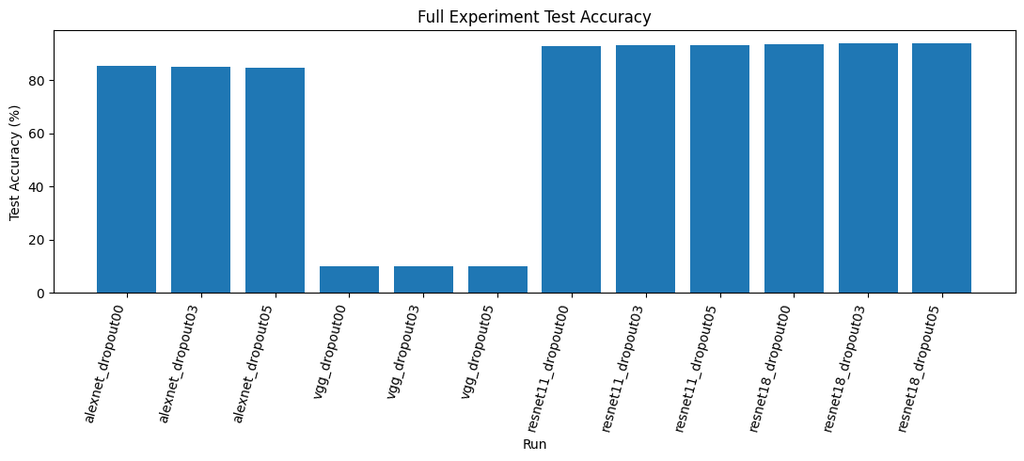

```
Saved summary table: results/full_experiment_summary.csv
Saved bar chart: results/full_experiment_accuracy_bar_chart.png
```

```python
summary_df = pd.DataFrame(all_results)

summary_path = RESULTS_DIR / "full_experiment_summary.csv"
summary_df.to_csv(summary_path, index=False)

display(summary_df.sort_values("test_accuracy", ascending=False))

plt.figure(figsize=(11, 5))
plt.bar(summary_df["run"], summary_df["test_accuracy"] * 100.0)
plt.xticks(rotation=75, ha="right")
plt.xlabel("Run")
plt.ylabel("Test Accuracy (%)")
plt.title("Full Experiment Test Accuracy")
plt.tight_layout()

chart_path = RESULTS_DIR / "full_experiment_accuracy_bar_chart.png"
plt.savefig(chart_path, dpi=200)
plt.show()

print("Saved summary table:", summary_path)
print("Saved bar chart:", chart_path)
```

## 14. Best model

```python
best_row = summary_df.loc[summary_df["test_accuracy"].idxmax()]

print("Best model based on test accuracy:")
display(best_row.to_frame(name="value"))
```

```
Best model based on test accuracy:
```

|  | value |
| --- | --- |
| run | resnet18_dropout03 |
| model | resnet18 |
| dropout | 0.3 |
| epochs | 50 |
| parameters | 11173962 |
| best_validation_accuracy | 0.943 |
| test_accuracy | 0.9394 |
| test_loss | 0.226434 |
| avg_epoch_time_sec | 3.324515 |
| device | cuda |

## 15. Display saved result images

```
results/full_experiment_accuracy_bar_chart.png
```

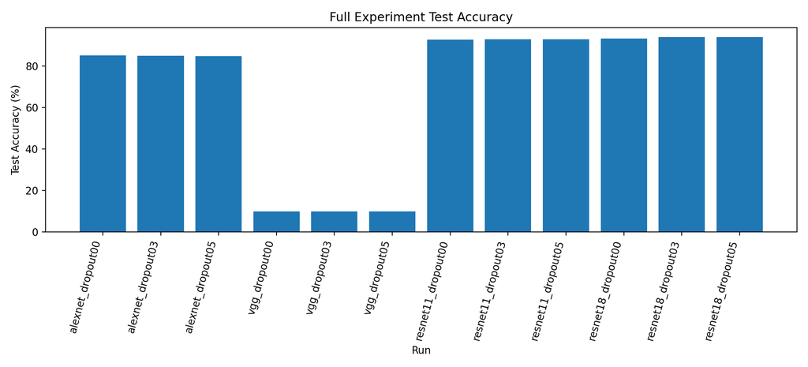

```
results/alexnet_dropout00/confusion_matrix.png
```

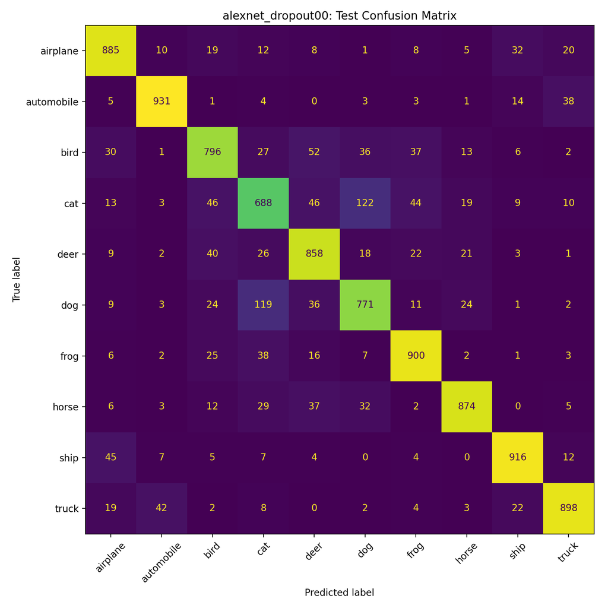

```
results/alexnet_dropout00/loss_curve.png
```

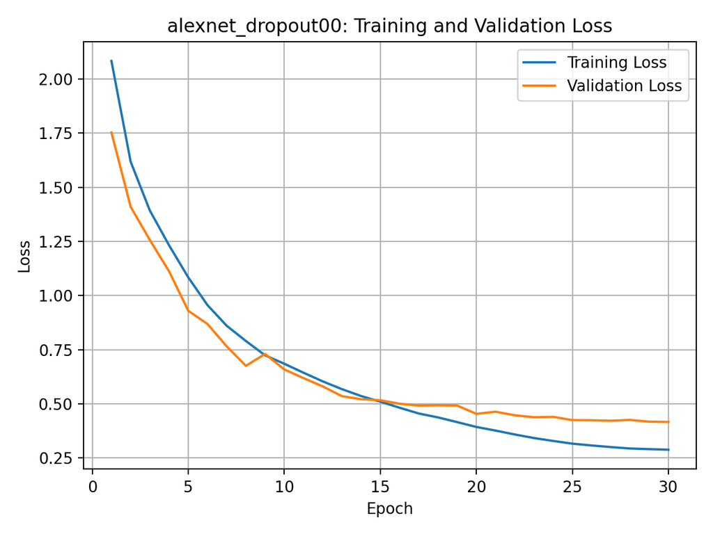

```
results/alexnet_dropout00/val_accuracy_curve.png
```

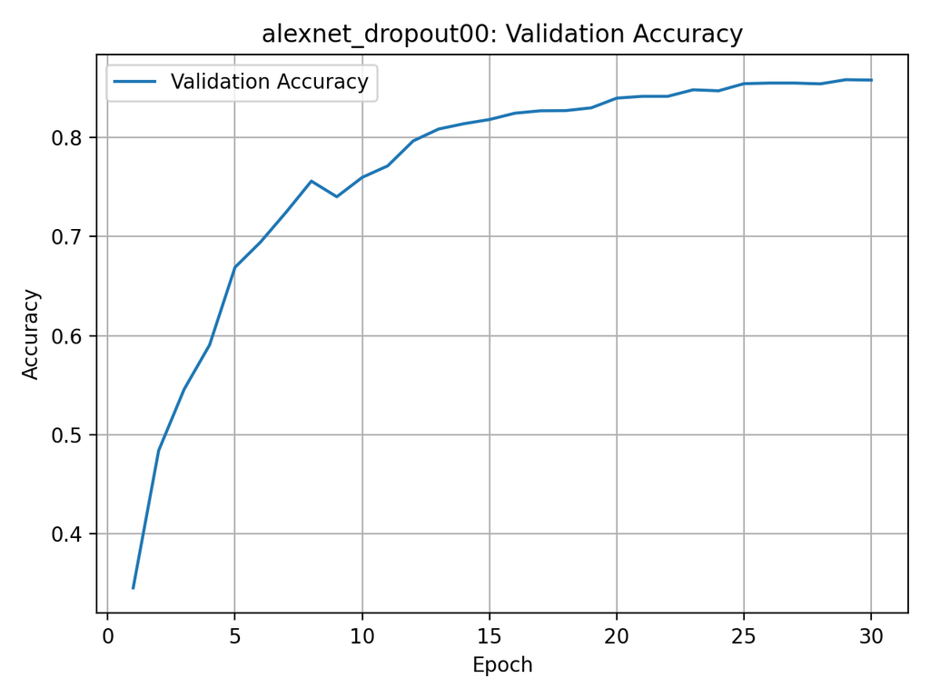

```
results/alexnet_dropout03/confusion_matrix.png
```

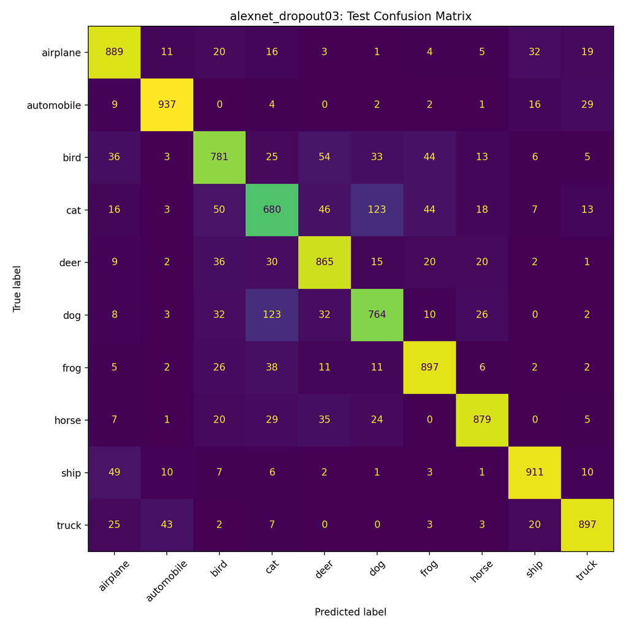

```
results/alexnet_dropout03/loss_curve.png
```

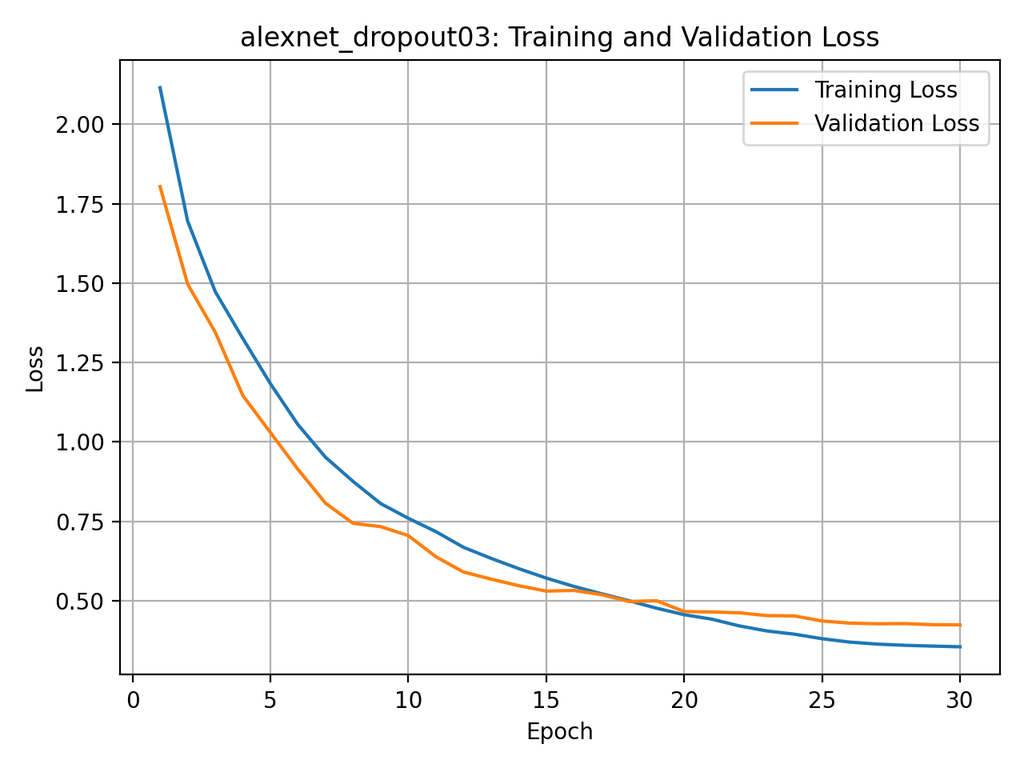

```
results/alexnet_dropout03/val_accuracy_curve.png
```

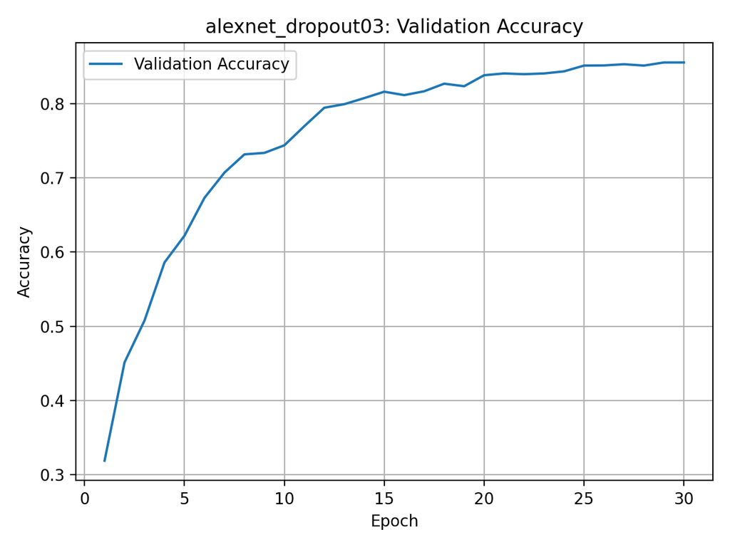

```
results/alexnet_dropout05/confusion_matrix.png
```

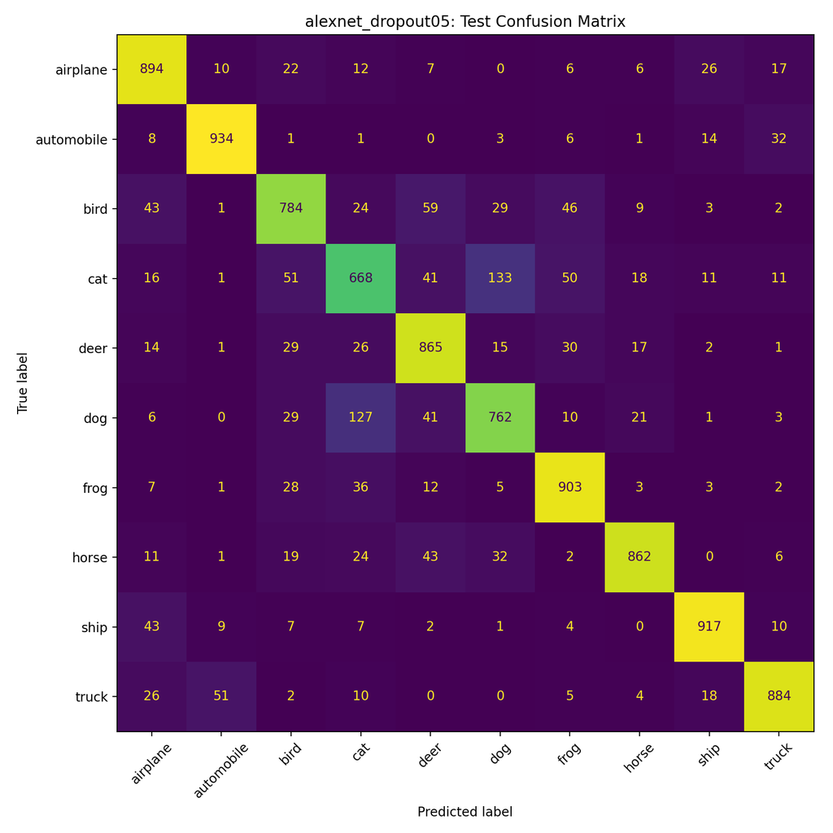

```
results/alexnet_dropout05/loss_curve.png
```

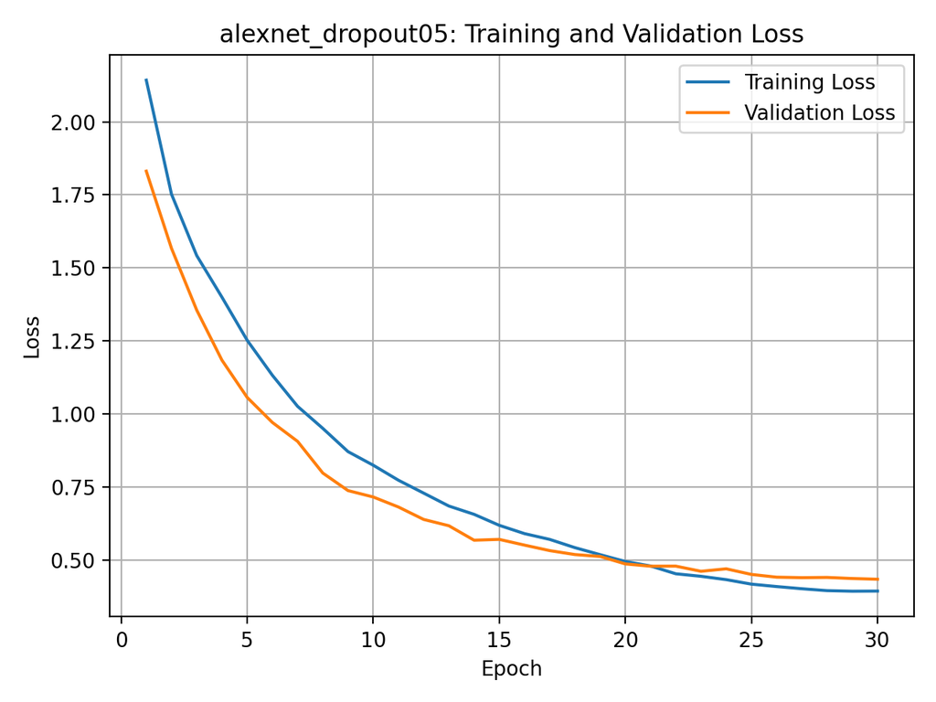

```
results/alexnet_dropout05/val_accuracy_curve.png
```

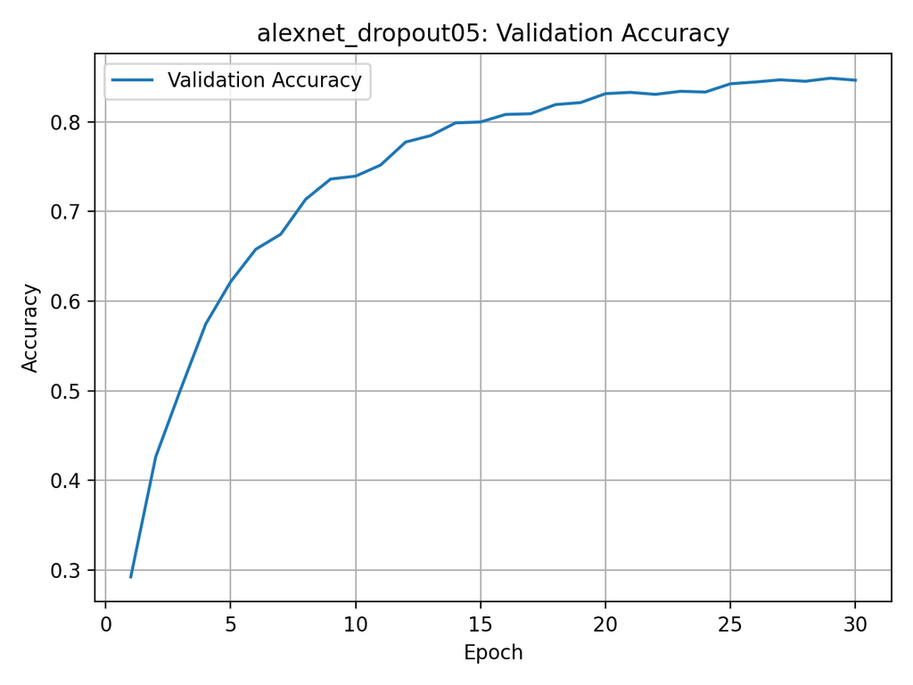

```
results/full_experiment_accuracy_bar_chart.png
```

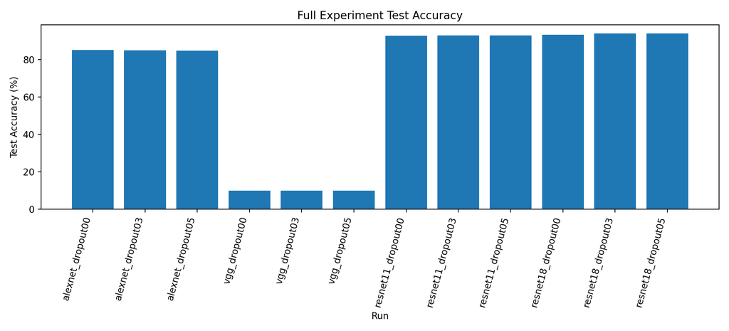

```
results/resnet11_dropout00/confusion_matrix.png
```

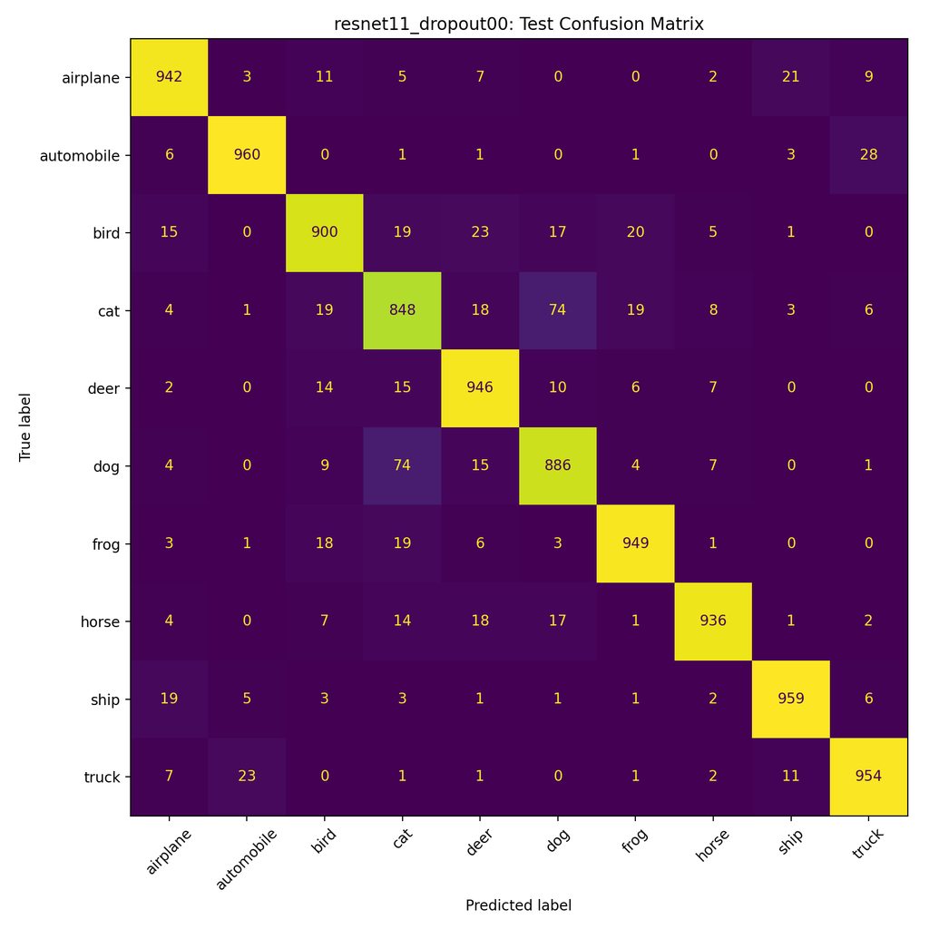

```
results/resnet11_dropout00/loss_curve.png
```

[26 more figures not shown]

```python
if chart_path.exists():
    print(chart_path)
    display(Image(filename=str(chart_path)))

for image_path in sorted(RESULTS_DIR.glob("**/*.png")):
    print(image_path)
    display(Image(filename=str(image_path)))
```